# stats506_hw4

github repo: https://github.com/juliahui/stats506_hw4.git

```r
#download package nzelect to use data nzge
#install.packages("remotes")

#remotes::install_version(
  #"nzelect",
  #repos = "https://cloud.r-project.org"
#)

#install.packages("infer")
```

```r
library(nzelect)
library(tidyverse)
library(infer) #t_test
library(ggplot2)
library(scales) #for labels = label_comma()
```

Problem 1 - Tidyverse: New Zealand

```r
nzge <- nzge
head(nzge)
```

```
  approx_location                 voting_place           party votes electorate
1          Albury                       School ACT New Zealand    16     Aoraki
2       Arowhenua Maori School, Huirapa Street ACT New Zealand     4     Aoraki
3      Burke Pass                  Alpine Café ACT New Zealand    13     Aoraki
4      Cannington                       School ACT New Zealand     6     Aoraki
5    Cattle Creek                       School ACT New Zealand     1     Aoraki
6            Cave                         Hall ACT New Zealand    16     Aoraki
  voting_type candidate election_year electorate_number
1       Party      <NA>          2002                 1
2       Party      <NA>          2002                 1
3       Party      <NA>          2002                 1
4       Party      <NA>          2002                 1
5       Party      <NA>          2002                 1
6       Party      <NA>          2002                 1
```

```r
#help(nzge)

vote_count <- nzge |>
  group_by(election_year, voting_type) |>
  summarize(num_votes = sum(votes)) |>
  arrange(num_votes) |>
  ungroup() |>
  rename(
    "Election Year" = election_year,
    "Voting Type" = voting_type,
    "Total Vote Count" = num_votes
  )
vote_count
```

```
# A tibble: 10 × 3
   `Election Year` `Voting Type` `Total Vote Count`
             <dbl> <chr>                      <dbl>
 1            2002 Candidate                2022115
 2            2002 Party                    2040248
 3            2011 Candidate                2225766
 4            2011 Party                    2257336
 5            2005 Candidate                2260670
 6            2005 Party                    2286190
 7            2008 Candidate                2325598
 8            2008 Party                    2356536
 9            2014 Candidate                2375493
10            2014 Party                    2416479
```

```r
#proportion of votes for each party in 2014 Candidate election
  #sorted by percent of vote
party_props <- nzge |>
  filter(election_year == 2014 & voting_type == "Candidate") |>
  group_by(party) |>
  summarize(num_votes = sum(votes)) |>
  mutate(vote_prop = num_votes / sum(num_votes)) |>
  arrange(desc(vote_prop)) |>
  ungroup() |>
    rename(
    "Party" = party,
    "Number of Votes" = num_votes,
    "Proportion of Total Votes" = vote_prop
  )
party_props
```

```
# A tibble: 25 × 3
   Party                    `Number of Votes` `Proportion of Total Votes`
   <chr>                                <dbl>                       <dbl>
 1 National Party                     1081787                     0.455
 2 Labour Party                        801287                     0.337
 3 Green Party                         165718                     0.0698
 4 Conservative Party                   81075                     0.0341
 5 New Zealand First Party              73384                     0.0309
 6 Maori Party                          42108                     0.0177
 7 MANA Movement                        32333                     0.0136
 8 Informal Candidate Votes             27886                     0.0117
 9 ACT New Zealand                      27778                     0.0117
10 United Future                        14722                     0.00620
# ℹ 15 more rows
```

```r
winning_party <- nzge |>
  group_by(election_year, voting_type, party) |>
  summarize(num_votes = sum(votes)) |>
  slice_max(order_by = num_votes, n = 1) |>
  ungroup() |>
  #just show year + winner
  select(-num_votes) |>
  pivot_wider(names_from = voting_type, values_from = party) |>
  rename(
    "Election Year" = election_year,
    "Candidate Vote Winner" = Candidate,
    "Party Vote Winner" = Party
  )
winning_party
```

```
# A tibble: 5 × 3
  `Election Year` `Candidate Vote Winner` `Party Vote Winner`
            <dbl> <chr>                   <chr>
1            2002 Labour Party            Labour Party
2            2005 National Party          Labour Party
3            2008 National Party          National Party
4            2011 National Party          National Party
5            2014 National Party          National Party
```

Problem 2 - Tidyverse: Tennis

Your answers should show both the output from R that allows you to answer it, as well as a written answer.

Referenced matches_data_dictionary.txt for variable names

```r
atp <- read.csv("atp_matches_2019.csv")
head(atp)
```

```
  tourney_id tourney_name surface draw_size tourney_level tourney_date
1  2019-M020     Brisbane    Hard        32             A     20181231
2  2019-M020     Brisbane    Hard        32             A     20181231
3  2019-M020     Brisbane    Hard        32             A     20181231
4  2019-M020     Brisbane    Hard        32             A     20181231
5  2019-M020     Brisbane    Hard        32             A     20181231
6  2019-M020     Brisbane    Hard        32             A     20181231
  match_num winner_id winner_seed winner_entry        winner_name winner_hand
1       300    105453           2                   Kei Nishikori           R
2       299    106421           4                 Daniil Medvedev           R
3       298    105453           2                   Kei Nishikori           R
4       297    104542          NA           PR Jo-Wilfried Tsonga           R
5       296    106421           4                 Daniil Medvedev           R
6       295    104871          NA                   Jeremy Chardy           R
  winner_ht winner_ioc winner_age loser_id loser_seed loser_entry
```

[output cut: 41 more lines]

1. How many tournaments took place in 2019?

```r
#https://www.statology.org/dplyr-count-distinct/ for idea
num_tournaments_2019 <- atp |>
  summarize("Number of tournaments" = n_distinct(tourney_id))
num_tournaments_2019
```

```
  Number of tournaments
1                   128
```

128 tournaments took place in 2019.

2. Did any player win more than one tournament? If so, how many players won more than one tournament, and how many tournaments did the most winning player(s) win?

```r
tournament_wins <- atp |>
  #based on documentation in github, F should be the final round
    #of a tournament -> winner should be tournament winner
  filter(round == "F") |>
  group_by(winner_name) |>
  #reminder: n() counts num rows in each group
  summarize(tournaments_won = n()) |>
  arrange(desc(tournaments_won)) |>
  ungroup()
tournament_wins
```

```
# A tibble: 41 × 2
   winner_name        tournaments_won
   <chr>                        <int>
 1 Dominic Thiem                    5
 2 Novak Djokovic                   5
 3 Daniil Medvedev                  4
 4 Rafael Nadal                     4
 5 Roger Federer                    4
 6 Alex De Minaur                   3
 7 Stefanos Tsitsipas               3
 8 Benoit Paire                     2
 9 Cristian Garin                   2
10 Jo-Wilfried Tsonga               2
# ℹ 31 more rows
```

```r
more_than_one <- tournament_wins |>
  filter(tournaments_won > 1)
more_than_one
```

```
# A tibble: 12 × 2
   winner_name        tournaments_won
   <chr>                        <int>
 1 Dominic Thiem                    5
 2 Novak Djokovic                   5
 3 Daniil Medvedev                  4
 4 Rafael Nadal                     4
 5 Roger Federer                    4
 6 Alex De Minaur                   3
 7 Stefanos Tsitsipas               3
 8 Benoit Paire                     2
 9 Cristian Garin                   2
10 Jo-Wilfried Tsonga               2
11 Matteo Berrettini                2
12 Nick Kyrgios                     2
```

```r
most_wins <- more_than_one |>
  slice_max(order_by = tournaments_won, with_ties = TRUE)
most_wins
```

```
# A tibble: 2 × 2
  winner_name    tournaments_won
  <chr>                    <int>
1 Dominic Thiem                5
2 Novak Djokovic               5
```

Yes, 12 players won more than one tournament. The players that won the most tournaments both won 5 (Dominic Thiem and Novak Djokovic).

3. Is there any evidence that winners have more aces than losers? (If you address this with a hypothesis test, do not use base R functionality - continue to remain in the Tidyverse.)

```r
aces_test <- atp |>
  mutate(num_aces_diff  = w_ace - l_ace) |>
  t_test(response = num_aces_diff, mu = 0, alternative = "greater")
aces_test
```

```
# A tibble: 1 × 7
  statistic  t_df  p_value alternative estimate lower_ci upper_ci
      <dbl> <dbl>    <dbl> <chr>          <dbl>    <dbl>    <dbl>
1      12.4  2693 1.53e-34 greater         1.70     1.48      Inf
```

The very small p-value (1.53e-34) means we reject the null that the difference between the number of winners’ aces and losers’ aces is 0. On average, it appears that winners have about 1.705 more aces than losers.

4. Identify the player(s) with the highest win-rate. (Note that this is NOT asking for the highest number of wins.) Restrict to players with at least 5 matches.

```r
#get number of matches won for each player
matches_won <- atp |>
  group_by(winner_name) |>
  summarize(matches_won = n()) |>
  arrange(matches_won) |>
  #for joining later
  rename(player_name = winner_name) |>
  ungroup()
head(matches_won)
```

```
# A tibble: 6 × 2
  player_name              matches_won
  <chr>                          <int>
1 Adrian Menendez Maceiras           1
2 Ajeet Rai                          1
3 Alejandro Gonzalez                 1
4 Aleksandre Metreveli               1
5 Alen Avidzba                       1
6 Alessandro Giannessi               1
```

```r
#get num of matches lost for each player
matches_lost <- atp |>
  group_by(loser_name) |>
  summarize(matches_lost = n()) |>
  arrange(matches_lost) |>
  rename(player_name = loser_name) |>
  ungroup()
head(matches_lost)
```

```
# A tibble: 6 × 2
  player_name                     matches_lost
  <chr>                                  <int>
1 Adam Moundir                               1
2 Adolfo Daniel Vallejo                      1
3 Adrian Andreev                             1
4 Ajeet Rai                                  1
5 Alastair Gray                              1
6 Alberto Emmanuel Alvarado Larin            1
```

```r
#join to get all the players' matches in one df
total_matches <- left_join(matches_won, matches_lost, by = "player_name") |>
  mutate(
    total_matches = matches_won + matches_lost,
    win_rate = matches_won / total_matches
  ) |>
  filter(total_matches >= 5) |>
  arrange(desc(win_rate)) |>
  slice_max(order_by = win_rate, with_ties = TRUE)
total_matches
```

```
# A tibble: 1 × 5
  player_name  matches_won matches_lost total_matches win_rate
  <chr>              <int>        <int>         <int>    <dbl>
1 Rafael Nadal          60            9            69    0.870
```

Rafael Nadal had the highest win rate, about 87%.

Problem 3 - Visualization

```r
#https://github.com/nytimes/covid-19-data/tree/master/rolling-averages
  #cases_avg: avg num of new cases reported over the most recent 7 days of data
us_states <- read.csv("us-states.csv")
head(us_states)
```

```
        date  geoid      state cases cases_avg cases_avg_per_100k deaths
1 2020-01-21 USA-53 Washington     1      0.14                  0      0
2 2020-01-22 USA-53 Washington     0      0.14                  0      0
3 2020-01-23 USA-53 Washington     0      0.14                  0      0
4 2020-01-24 USA-53 Washington     0      0.14                  0      0
5 2020-01-24 USA-17   Illinois     1      0.14                  0      0
6 2020-01-25 USA-53 Washington     0      0.14                  0      0
  deaths_avg deaths_avg_per_100k
1          0                   0
2          0                   0
3          0                   0
4          0                   0
5          0                   0
6          0                   0
```

```r
#unique(us_states$state)
```

1. How many major and minor spikes in cases were there?

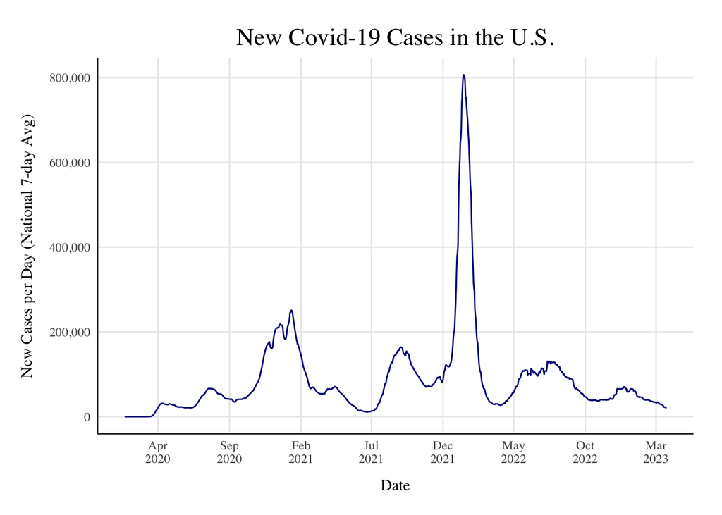

```r
#https://www.r-bloggers.com/2023/11/getting-started-with-theme/

#tried just raw data, plot wasn't clear enough
  #use 7 day averages instead
us_states_a <- us_states |>
  group_by(date) |>
    #line idea from um-gpt
  summarize(cases_avg = sum(cases_avg)) |>
  ungroup()

plot_a <- us_states_a |>
  ggplot(mapping = aes(x = as.Date(date), y = cases_avg)) +
  geom_line(color = "darkblue") +
  scale_x_date(date_breaks = "5 months", date_labels = "%b\n%Y") +
  #https://stackoverflow.com/questions/14563989/force-r-to-stop-plotting-abbreviated-axis-labels-scientific-notation-e-g-1e
  scale_y_continuous(labels = label_comma()) +
  labs(title = "New Covid-19 Cases in the U.S.",
       x = "Date", y = "New Cases per Day (National 7-day Avg)") +
  theme_minimal() +
  theme(
    #makes the axes more visible
    axis.line = element_line(colour = "grey20"),
    #gets rid of the minor grid lines for cleaner look
    panel.grid.minor = element_blank(),
    #modify font
    text = element_text(family = "serif"),
    #adjust plot title
    plot.title = element_text(hjust = 0.5, size = 17),
    #pushes y axis label to the left
    axis.title.y = element_text(margin = margin(r = 10)),
    #pushes x axis label down
    axis.title.x = element_text(margin = margin(t = 10)),
    #add more space around edges of plot
    plot.margin = margin(t = 20, r = 20, b = 15, l = 15)
  )
plot_a
```

There seems to be one major spike between about December 2021 and March 2022. Aside from this very clear spike, there’s 3 minor spikes from November 2020 to February 2021, August 2021 to November 2021, and May 2022-September 2022.

2. For the states with the highest and lowest overall rates per population, what differences do you see in their trajectories over time?

```r
not_states <- c("District of Columbia", "Puerto Rico", "Guam", "Virgin Islands",
            "Northern Mariana Islands", "American Samoa")

states_only <- us_states |>
  #keep states only
  filter(!(state %in% not_states))

#assuming cases_avg_per_100k is rate per popul (based on github)
us_states_b <- states_only |>
  group_by(state) |>
  summarize(overall_rate = sum(cases_avg_per_100k)) |>
  arrange(desc(overall_rate)) |>
  ungroup()
head(us_states_b)
```

```
# A tibble: 6 × 2
  state         overall_rate
  <chr>                <dbl>
1 Rhode Island        43296.
2 Alaska              41835.
3 Kentucky            39042.
4 North Dakota        37604.
5 Tennessee           36181.
6 West Virginia       35982.
```

```r
#unique(us_states_b$state) #just to check

highest_overall_rate <- us_states_b |>
  slice_max(order_by = overall_rate)

lowest_overall_rate <- us_states_b |>
  slice_min(order_by = overall_rate)

#just get the states' names for plotting
rates <- c(highest_overall_rate$state, lowest_overall_rate$state)
rates
```

```
[1] "Rhode Island" "Maine"
```

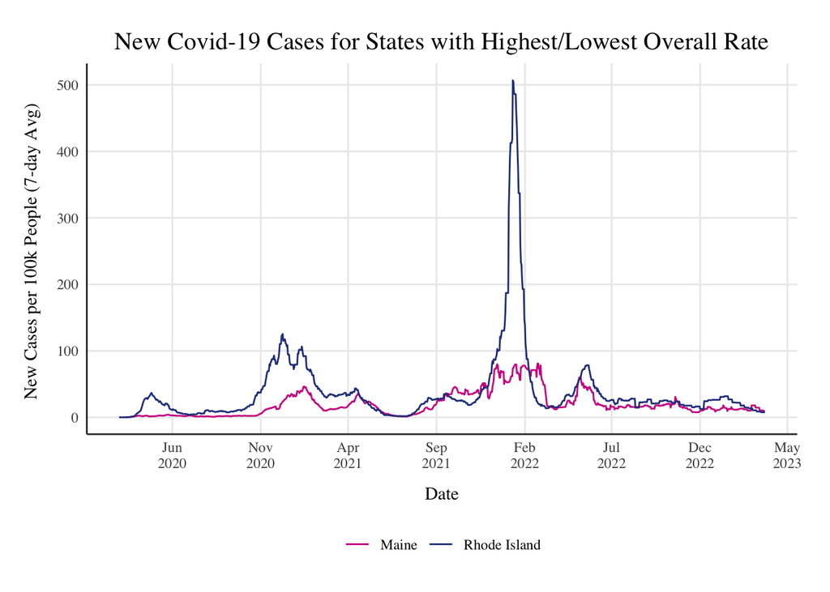

```r
plot_b <- states_only |>
  filter(state %in% rates) |>
  ggplot(mapping = aes(x = as.Date(date),
                       y = cases_avg_per_100k, color = state)) +
  geom_line() +
  scale_x_date(date_breaks = "5 months", date_labels = "%b\n%Y") +
  labs(title = "New Covid-19 Cases for States with Highest/Lowest Overall Rate",
       x = "Date", y = "New Cases per 100k People (7-day Avg) ") +
  scale_color_manual(name = NULL, values = c("violetred", "royalblue4")) +
  theme_minimal() +
  theme(
    #makes the axes more visible
    axis.line = element_line(colour = "grey20"),
    #gets rid of the minor grid lines for cleaner look
    panel.grid.minor = element_blank(),
    #modify font
    text = element_text(family = "serif"),
    #adjust plot title
    plot.title = element_text(hjust = 0.5, size = 15),
    #pushes y axis label to the left
    axis.title.y = element_text(margin = margin(r = 10)),
    #pushes x axis label down
    axis.title.x = element_text(margin = margin(t = 10)),
    #add more space around edges of plot
    plot.margin = margin(t = 20, r = 20, b = 15, l = 15),
    legend.position = "bottom"
  )
plot_b
```

Rhode Island had the highest overall rate, and Maine had the lowest. The differ mostly in periods where Rhode Island experiences an increase in the average number of new cases while Maine stays relatively constant, or experiences a smaller increase. For example, between about December 2021 and March 2022, Rhode Island experiences a huge spike in the average number of new cases, while Maine’s numbers are mostly constant.

3. Identify, to the best of your ability without a formal test, the first five states to experience Covid in a substantial way.

```r
#first date each state reached 25 new daily cases per 100,000 people
first_five <- states_only |>
  filter(cases_avg_per_100k >= 25) |>
  group_by(state) |>
  summarize(first_date = min(date)) |>
  arrange(first_date) |>
  ungroup() |>
  slice_head(n = 5)
first_five
```

```
# A tibble: 5 × 2
  state         first_date
  <chr>         <chr>
1 New York      2020-03-26
2 New Jersey    2020-04-01
3 Louisiana     2020-04-04
4 Connecticut   2020-04-12
5 Massachusetts 2020-04-12
```

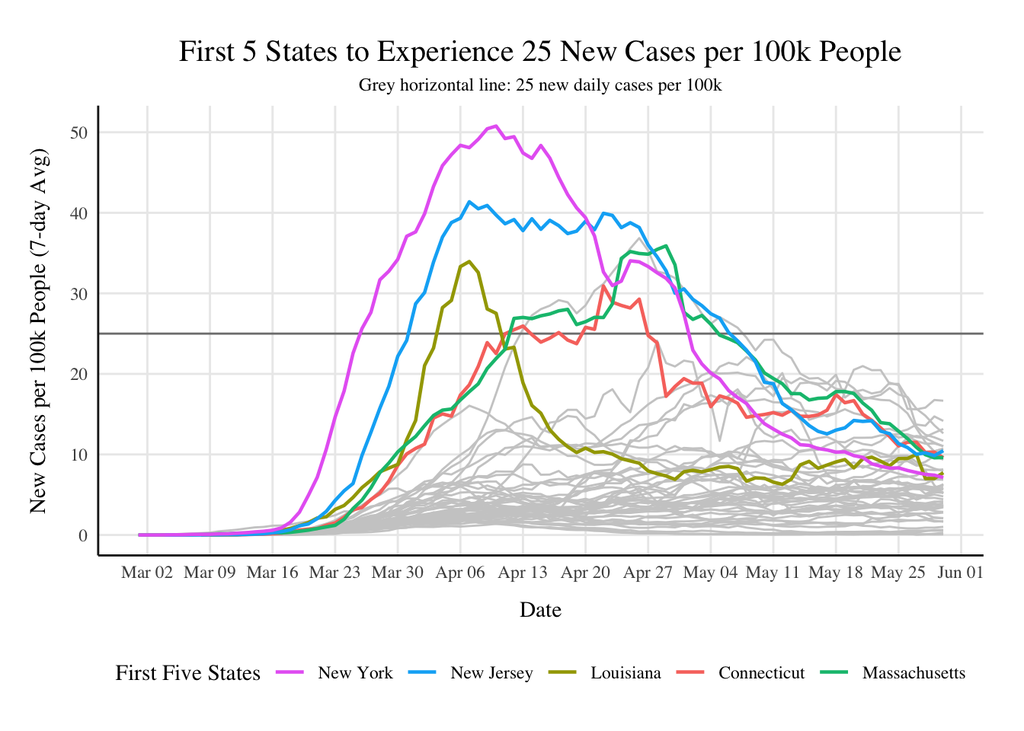

```r
#beginning of pandemic (for plotting) (checked when cases started increasing)
pandemic_start <- states_only |>
  filter(date >= as.Date("2020-03-01"), date <= as.Date("2020-05-30"))

plot_c <- pandemic_start|>
  ggplot(mapping = aes(x = as.Date(date), y = cases_avg_per_100k)) +
  #grey lines for every state
  geom_line(aes(group = state), color = "grey80") +
  geom_hline(yintercept = 25, color = "grey50") +
  #colored lines on top for the first five states
  geom_line(data = filter(pandemic_start, state %in% first_five$state),
            aes(color = state), linewidth = 0.8) +
  scale_x_date(date_breaks = "1 week", date_labels = "%b %d") +
  labs(title = "First 5 States to Experience 25 New Cases per 100k People",
       x = "Date", y = "New Cases per 100k People (7-day Avg)",
       subtitle = "Grey horizontal line: 25 new daily cases per 100k") +
  scale_color_discrete(name = "First Five States", breaks = first_five$state) +
  theme_minimal() +
  theme(
    #makes the axes more visible
    axis.line = element_line(colour = "grey10"),
    #gets rid of the minor grid lines for cleaner look
    panel.grid.minor = element_blank(),
    #modify font
    text = element_text(family = "serif"),
    #adjust plot title
    plot.title = element_text(hjust = 0.5, size = 15),
    plot.subtitle = element_text(hjust = 0.5, size = 9),
    #pushes y axis label to the left
    axis.title.y = element_text(margin = margin(r = 10)),
    #pushes x axis label down
    axis.title.x = element_text(margin = margin(t = 10)),
    #add more space around edges of plot
    plot.margin = margin(t = 20, r = 20, b = 15, l = 15),
    legend.position = "bottom"
  )
plot_c
```

The first five states to experience Covid in a substantial way, which I defined as reaching a 7-day average of at least 25 new cases per 100k people, were New York, New Jersey, Louisiana, Connecticut, and Massachusetts.